# Analyzing our Quick Survey

2022-09-03

```r
knitr::opts_chunk$set(comment=NA)
options(width = 70)
```

# Load Packages and Set Theme

```r
library(janitor)
library(patchwork)
library(tidyverse)

theme_set(theme_bw())
```

# Load Data

Our data come from the Quick 15-item Survey we did in Class 02 ([pdf in Class 02 README](https://github.com/THOMASELOVE/431-classes-2022/tree/main/class02)), which we’ve done (in various forms) since 2014.

```r
## if you want to load in a data set called namebeta.csv
## and then create a tibble from it called namealpha
## then uncomment the next line by removing the #

quicksur_raw <-
  read_csv("quick_survey_2022.csv", show_col_types = FALSE) |>
  clean_names()
```

# 1 Our Questions of Interest

We’ll tackle several exploratory questions of interest…

1. What is the distribution of pulse rates among students in 431 since 2014?
2. Does the distribution of student heights change materially over time?
3. Is a Normal distribution is a good model for our data?
4. Do taller people appear to have paid less for their most recent haircut?
5. Do students have a more substantial tobacco history if they prefer to speak English or a language other than English?

# 2 Initial Cleaning

## 2.1 What does the `quicksur_raw` tibble include?

```r
quicksur_raw
```

```
# A tibble: 494 × 23
   student glasses english statsofar love_htcm smoke h_left h_right
     <dbl> <chr>   <chr>       <dbl>     <dbl> <dbl>  <dbl>   <dbl>
 1  202201 n       n               5       180     1      1       9
 2  202202 y       y               7       168     1      0      10
 3  202203 n       y               5       185     2      0      10
 4  202204 y       y               6       185     1      0      10
 5  202205 y       y               6       191     1     16       4
 6  202206 y       y               6       183     2      3      15
 7  202207 y       y               7       188     1     18      10
 8  202208 n       n               7       188     1      4      10
 9  202209 y       y               7       191     2      1      19
10  202210 n       y               6       183     1      6      13
# … with 484 more rows, and 15 more variables: handedness <chr>,
#   statfuture <dbl>, haircut <dbl>, lecture <dbl>, alone <dbl>,
#   height_in <dbl>, hand_span <dbl>, favcolor <chr>,
#   lastsleep <dbl>, pulse <dbl>, sex <chr>, ageguess <dbl>,
#   year <dbl>, lovetrueage <dbl>, lovetrueht <dbl>
```

```r
glimpse(quicksur_raw)
```

```
Rows: 494
Columns: 23
$ student     <dbl> 202201, 202202, 202203, 202204, 202205, 202206, …
$ glasses     <chr> "n", "y", "n", "y", "y", "y", "y", "n", "y", "n"…
$ english     <chr> "n", "y", "y", "y", "y", "y", "y", "n", "y", "y"…
$ statsofar   <dbl> 5, 7, 5, 6, 6, 6, 7, 7, 7, 6, 5, 3, 5, 6, 4, 5, …
$ love_htcm   <dbl> 180, 168, 185, 185, 191, 183, 188, 188, 191, 183…
$ smoke       <dbl> 1, 1, 2, 1, 1, 2, 1, 1, 2, 1, 1, 1, 1, 1, 1, 1, …
$ h_left      <dbl> 1, 0, 0, 0, 16, 3, 18, 4, 1, 6, 7, 0, 0, 4, 0, 4…
$ h_right     <dbl> 9, 10, 10, 10, 4, 15, 10, 10, 19, 13, 12, 16, 16…
$ handedness  <chr> "0.8", "1", "1", "1", "1", "1", "1", "1", "1", "…
$ statfuture  <dbl> 6, 7, 7, 7, 7, 7, 7, 7, 7, 6, 7, 7, 7, 7, 5, 7, …
$ haircut     <dbl> 2, 50, 0, 38, 25, 15, 0, 32, 60, 40, 45, 52, 52,…
$ lecture     <dbl> 2, 3, 2, 1, 3, 3, 2, 3, 2, 3, 3, 3, 3, 3, 3, 3, …
$ alone       <dbl> 4, 1, 2, 3, 3, 3, 3, 2, 4, 4, 3, 3, 2, 2, 3, 3, …
$ height_in   <dbl> 69.5, 63.0, 73.0, 70.0, 59.0, 68.0, 71.0, 70.0, …
$ hand_span   <dbl> 23.0, 19.0, 25.0, 23.5, 17.0, 22.0, 23.0, 23.0, …
$ favcolor    <chr> "blue", "purple", NA, "green", "red", "royal pur…
$ lastsleep   <dbl> 5.0, 4.0, 7.0, 6.0, 6.0, 7.0, 7.0, 6.0, 8.0, 7.0…
$ pulse       <dbl> 80, 64, 68, 88, 60, 72, 68, 68, 96, 66, 64, 88, …
$ sex         <chr> NA, NA, NA, NA, NA, NA, NA, NA, NA, NA, NA, NA, …
$ ageguess    <dbl> NA, NA, NA, NA, NA, NA, NA, NA, NA, NA, NA, NA, …
$ year        <dbl> 2022, 2022, 2022, 2022, 2022, 2022, 2022, 2022, …
$ lovetrueage <dbl> 55.5, 55.5, 55.5, 55.5, 55.5, 55.5, 55.5, 55.5, …
$ lovetrueht  <dbl> 190, 190, 190, 190, 190, 190, 190, 190, 190, 190…
```

## 2.2 Counting Categories

```r
quicksur_raw |> count(glasses)
```

```
# A tibble: 3 × 2
  glasses     n
  <chr>   <int>
1 n          78
2 y         162
3 <NA>      254
```

```r
quicksur_raw |> count(glasses, english)
```

```
# A tibble: 8 × 3
  glasses english     n
  <chr>   <chr>   <int>
1 n       n          20
2 n       y          58
3 y       n          34
4 y       y         127
5 y       <NA>        1
6 <NA>    n          47
7 <NA>    y         205
8 <NA>    <NA>        2
```

## 2.3 Favorite Color in 2022?

```r
quicksur_raw |>
    filter(year == "2022") |>
    tabyl(favcolor) |>
    adorn_pct_formatting()
```

```
      favcolor  n percent valid_percent
   all of them  1    1.9%          1.9%
         black  2    3.7%          3.8%
          blue 24   44.4%         45.3%
         green  8   14.8%         15.1%
        maroon  1    1.9%          1.9%
        orange  4    7.4%          7.5%
          pink  1    1.9%          1.9%
        purple  2    3.7%          3.8%
           red  6   11.1%         11.3%
  royal purple  1    1.9%          1.9%
 seafoam green  1    1.9%          1.9%
         white  2    3.7%          3.8%
          <NA>  1    1.9%             -
```

## 2.4 Using `summary()` on Quantities

```r
quicksur_raw |>
  select(love_htcm, haircut, height_in, lastsleep) |>
  summary()
```

```
   love_htcm        haircut         height_in       lastsleep
 Min.   :165.0   Min.   :  0.00   Min.   :57.00   Min.   : 2.00
 1st Qu.:178.0   1st Qu.: 14.00   1st Qu.:64.00   1st Qu.: 6.00
 Median :183.0   Median : 20.00   Median :67.00   Median : 7.00
 Mean   :182.5   Mean   : 30.17   Mean   :67.33   Mean   : 6.94
 3rd Qu.:188.0   3rd Qu.: 40.00   3rd Qu.:70.00   3rd Qu.: 8.00
 Max.   :191.0   Max.   :250.00   Max.   :77.50   Max.   :12.00
 NA's   :385     NA's   :9        NA's   :7       NA's   :6
```

- Numerical summaries (five quantiles, plus the mean) for:
  - your guess of my height (in cm), the price of your last haircut, your height (in inches), and the hours of sleep you got last night
- How many observations are available for these measures?

# 3 Manage the data into `qsdat`

## 3.1 Variables we’ll look at closely today

To address our Questions of Interest, we need these seven variables in our analytic data frame (tibble.)

- `student`: student identification (numerical code)
- `year`: indicates year when survey was taken (August)
- `english`: y = prefers to speak English, else n
- `smoke`: 1 = never smoker, 2 = quit, 3 = current
- `pulse`: pulse rate (beats per minute)
- `height_in`: student’s height (in inches)
- `haircut`: price of student’s last haircut (in $)

## 3.2 Select our variables

```r
qsdat <- quicksur_raw |>
    select(student, year, english, smoke,
           pulse, height_in, haircut)

qsdat
```

```
# A tibble: 494 × 7
   student  year english smoke pulse height_in haircut
     <dbl> <dbl> <chr>   <dbl> <dbl>     <dbl>   <dbl>
 1  202201  2022 n           1    80      69.5       2
 2  202202  2022 y           1    64      63        50
 3  202203  2022 y           2    68      73         0
 4  202204  2022 y           1    88      70        38
 5  202205  2022 y           1    60      59        25
 6  202206  2022 y           2    72      68        15
 7  202207  2022 y           1    68      71         0
 8  202208  2022 n           1    68      70        32
 9  202209  2022 y           2    96      69        60
10  202210  2022 y           1    66      76        40
# … with 484 more rows
```

## 3.3 Initial Numeric Summaries

- Is everything the “type” of variable it should be?
- Are we getting the summaries we want?

```r
summary(qsdat)
```

```
    student            year        english              smoke
 Min.   :201401   Min.   :2014   Length:494         Min.   :1.000
 1st Qu.:201633   1st Qu.:2016   Class :character   1st Qu.:1.000
 Median :201845   Median :2018   Mode  :character   Median :1.000
 Mean   :201848   Mean   :2018                      Mean   :1.089
 3rd Qu.:202056   3rd Qu.:2020                      3rd Qu.:1.000
 Max.   :202254   Max.   :2022                      Max.   :3.000
                                                    NA's   :2
     pulse          height_in        haircut
 Min.   : 30.00   Min.   :57.00   Min.   :  0.00
 1st Qu.: 65.00   1st Qu.:64.00   1st Qu.: 14.00
 Median : 72.00   Median :67.00   Median : 20.00
 Mean   : 73.57   Mean   :67.33   Mean   : 30.17
 3rd Qu.: 80.00   3rd Qu.:70.00   3rd Qu.: 40.00
 Max.   :110.00   Max.   :77.50   Max.   :250.00
 NA's   :75       NA's   :7       NA's   :9
```

## 3.4 What should we be seeing?

- Categorical variables should list the categories, with associated counts.
  - To accomplish this, the variable needs to be represented in R with a `factor`, rather than as a `character` or `numeric` variable.
- Quantitative variables should show the minimum, median, mean, maximum, etc.

```r
names(qsdat)
```

```
[1] "student"   "year"      "english"   "smoke"     "pulse"
[6] "height_in" "haircut"
```

## 3.5 Change categorical variables to factors

We want the `year` and `smoke` information treated as categorical, rather than as quantitative, and the `english` information as a factor, too. Also, do we want to summarize the student ID codes?

- We use the `mutate()` function to help with this.

```r
qsdat <- qsdat |>
    mutate(year = as_factor(year),
           smoke = as_factor(smoke),
           english = as_factor(english),
           student = as.character(student))
```

- Note that it’s `as_factor()` but `as.character()`. Sigh.

## 3.6 Next step: Recheck the summaries and do range checks

- Do these summaries make sense?
- Are the minimum and maximum values appropriate?
- How much missingness are we to deal with?

```r
summary(qsdat)
```

```
   student               year     english     smoke
 Length:494         2020   : 67   n   :101   1   :456
 Class :character   2016   : 64   y   :390   2   : 28
 Mode  :character   2019   : 61   NA's:  3   3   :  8
                    2021   : 58              NA's:  2
                    2022   : 54
                    2018   : 51
                    (Other):139
     pulse          height_in        haircut
 Min.   : 30.00   Min.   :57.00   Min.   :  0.00
 1st Qu.: 65.00   1st Qu.:64.00   1st Qu.: 14.00
 Median : 72.00   Median :67.00   Median : 20.00
 Mean   : 73.57   Mean   :67.33   Mean   : 30.17
 3rd Qu.: 80.00   3rd Qu.:70.00   3rd Qu.: 40.00
 Max.   :110.00   Max.   :77.50   Max.   :250.00
 NA's   :75       NA's   :7       NA's   :9
```

## 3.7 What to look for…

- Are we getting counts for all variables that are categorical?
  - Do the category levels make sense?
- Are we getting means and medians for all variables that are quantities?
  - Do the minimum and maximum values make sense for each of these quantities?
- Which variables have missing data, as indicated by `NA's`?

## 3.8 The summary for `year` is an issue

- Just to fill in the gap left by the `summary()` result, how many students responded each year?

```r
qsdat |> tabyl(year) |> adorn_totals() |> adorn_pct_formatting()
```

```
  year   n percent
  2014  42    8.5%
  2015  49    9.9%
  2016  64   13.0%
  2017  48    9.7%
  2018  51   10.3%
  2019  61   12.3%
  2020  67   13.6%
  2021  58   11.7%
  2022  54   10.9%
 Total 494  100.0%
```

# 4 Question 1

1. What is the distribution of pulse rates among students in 431 since 2014?

## 4.1 Histogram, first try

- What is the distribution of student `pulse` rates?

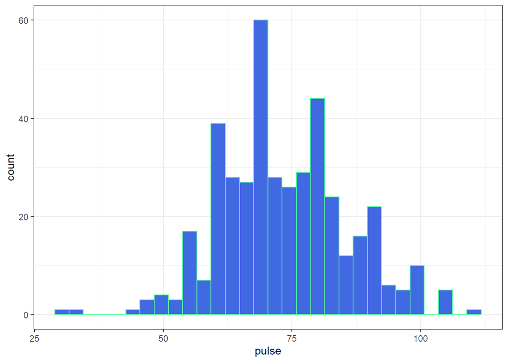

```r
ggplot(data = qsdat, aes(x = pulse)) +
    geom_histogram(bins = 30, fill = "royalblue", col = "seagreen1")
```

## 4.2 Describing the Pulse Rates

How might we describe this distribution?

- What is the center?
- How much of a range around that center do we see? How spread out are the data?
- What is the shape of this distribution?
  - Is it symmetric, or is it skewed to the left or to the right?

## 4.3 Fundamental Numerical Summaries

```r
qsdat |> select(pulse) |> summary()
```

```
     pulse
 Min.   : 30.00
 1st Qu.: 65.00
 Median : 72.00
 Mean   : 73.57
 3rd Qu.: 80.00
 Max.   :110.00
 NA's   :75
```

- How do the summary statistics help us describe the data?
- Do the values make sense to you?

```r
mosaic::favstats(~ pulse, data = qsdat)
```

```
 min Q1 median Q3 max     mean      sd   n missing
  30 65     72 80 110 73.57041 12.3539 419      75
```

## 4.4 Histogram, version 2

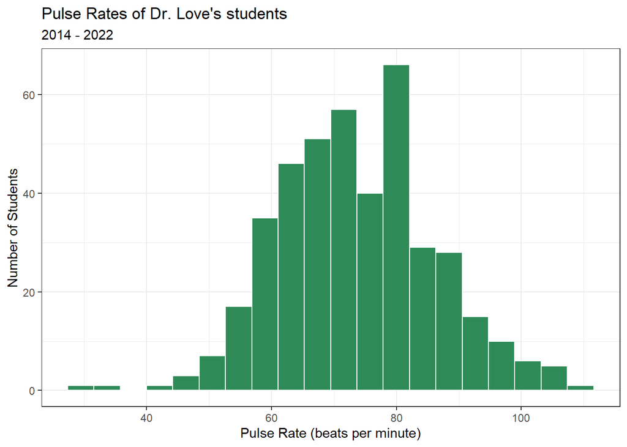

```r
dat1 <- qsdat |>
  filter(complete.cases(pulse))

ggplot(data = dat1, aes(x = pulse)) +
    geom_histogram(fill = "seagreen", col = "white", bins = 20) +
    labs(title = "Pulse Rates of Dr. Love's students",
         subtitle = "2014 - 2022",
         y = "Number of Students",
         x = "Pulse Rate (beats per minute)")
```

- How did we deal with missing data?
- How did we add axis labels and titles to the plot?
- What is the distinction between `fill` and `col`?
- How many bins should we use?

# 5 Question 2

2. Does the distribution of student heights change materially over time?

## 5.1 Yearly Five-Number Summaries

```r
qsdat |>
    filter(complete.cases(height_in)) |>
    group_by(year) |>
    summarize(n = n(), min = min(height_in), q25 = quantile(height_in, 0.25),
              median = median(height_in), q75 = quantile(height_in, 0.75),
              max = max(height_in))
```

```
# A tibble: 9 × 7
  year      n   min   q25 median   q75   max
  <fct> <int> <dbl> <dbl>  <dbl> <dbl> <dbl>
1 2014     40    60  64.8   68    71    73
2 2015     49    61  65     68    70    74
3 2016     64    60  64     67    70    76
4 2017     48    62  65     67    69    77
5 2018     51    60  63     66    70    73
6 2019     60    57  65     68    70    77.5
7 2020     66    59  63     66    69.8  76
8 2021     55    60  64.5   67.5  71    77.5
9 2022     54    59  66     68.5  70.4  76
```

- Does the distribution of heights change materially in 2014-2022?

## 5.2 Five-Number Summary

- Key summaries based on percentiles / quantiles
  - minimum = 0th, maximum = 100th, median = 50th
  - quartiles (25th, 50th and 75th percentiles)
  - Range is maximum - minimum
  - IQR (inter-quartile range) is 75th - 25th percentile
- These summaries are generally more resistant to outliers than mean, standard deviation
- Form the elements of a boxplot (box-and-whisker plot)

## 5.3 Comparison Boxplot of Heights by Year

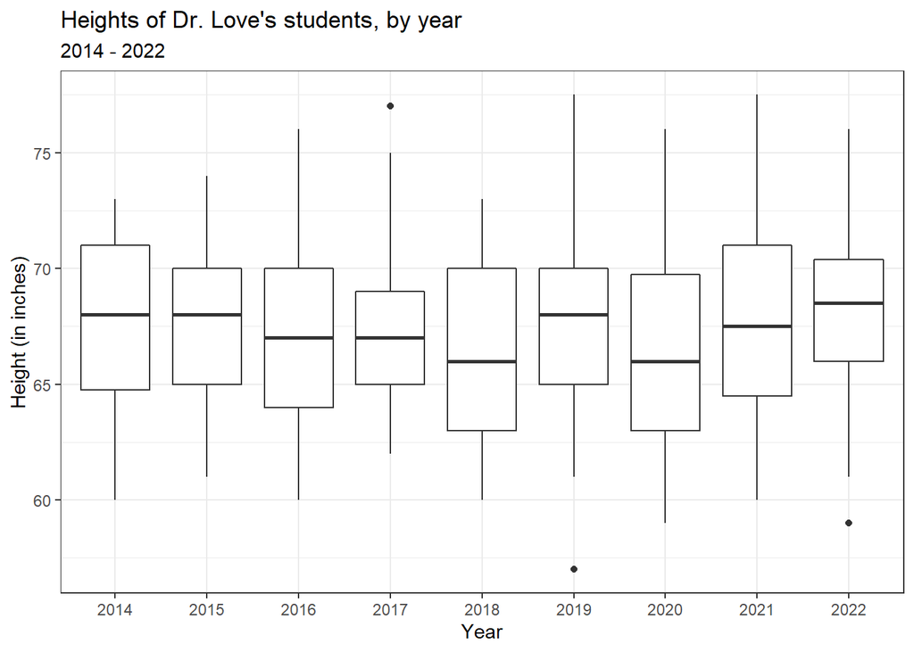

```r
dat2 <- qsdat |>
    filter(complete.cases(height_in))

ggplot(data = dat2, aes(x = year, y = height_in)) +
    geom_boxplot() +
    labs(title = "Heights of Dr. Love's students, by year",
         subtitle = "2014 - 2022", x = "Year", y = "Height (in inches)")
```

## 5.4 Thinking about the Boxplot

- Box covers the middle half of the data (25th and 75th percentiles), and the solid line indicates the median
- Whiskers extend from the quartiles to the most extreme values that are not judged by **Tukey’s** “fences” method to be candidate outliers
  - Fences are drawn at 25th percentile - 1.5 IQR and 75th percentile + 1.5 IQR
- Are any values candidate outliers by this method? For which years?
- Was it important to change `year` to a factor earlier?

## 5.5 Adding a Violin to the Boxplot

- When we’d like to better understand the shape of a distribution, we can amplify the boxplot.

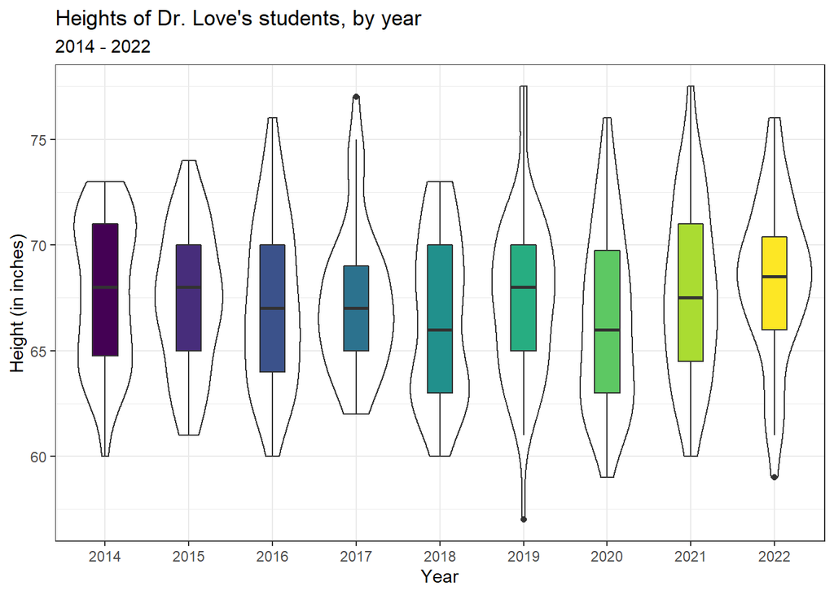

```r
dat2 <- qsdat |>
    filter(complete.cases(height_in))

ggplot(data = dat2, aes(x = year, y = height_in)) +
    geom_violin() +
    geom_boxplot(aes(fill = year), width = 0.3) +
    guides(fill = "none") +
    scale_fill_viridis_d() +
    labs(title = "Heights of Dr. Love's students, by year",
         subtitle = "2014 - 2022", x = "Year", y = "Height (in inches)")
```

- How did we change the boxplot when we added the violin?
- What would happen if we added the boxplot first and the violin second?
- What does `guides(fill = "none")` do?
- What does `scale_fill_viridis_d()` do?

## 5.6 Table of Means and Standard Deviations

```r
qsdat |>
    filter(complete.cases(height_in)) |>
    group_by(year) |>
    summarize(n = n(), mean = mean(height_in), sd = sd(height_in))
```

```
# A tibble: 9 × 4
  year      n  mean    sd
  <fct> <int> <dbl> <dbl>
1 2014     40  67.8  3.46
2 2015     49  67.3  3.32
3 2016     64  67.2  3.86
4 2017     48  67.4  3.46
5 2018     51  66.5  3.81
6 2019     60  67.4  3.83
7 2020     66  66.4  4.09
8 2021     55  67.8  4.13
9 2022     54  68.4  3.74
```

# 6 Question 3

3. Is a Normal distribution is a good model for our data?
- A Normal distribution is completely specified by its mean and standard deviation. The “bell shape” doesn’t change.

## 6.1 Summarizing Quantitative Data

If the data followed a Normal model,

- we would be justified in using the sample **mean** to describe the center, and
- in using the sample **standard deviation** to describe the spread (variation.)

But it is often the case that these measures aren’t robust enough, because the data show meaningful skew (asymmetry), or the data have lighter or heavier tails than a Normal model would predict.

## 6.2 The Empirical Rule for Approximately Normal Distributions

If the data followed a Normal distribution,

- approximately 68% of the data would be within 1 SD of the mean,
- approximately 95% of the data would be within 2 SD of the mean, while
- essentially all (99.7%) of the data would be within 3 SD of the mean.

## 6.3 The Empirical Rule and 2022 Student Heights

In 2022, we had 54 students whose `height_in` was available, with mean 68.4 inches (173.7 cm) and standard deviation 3.7 inches (9.4 cm).

What do the histogram and boxplot (seen earlier) suggest about whether a Normal model with this mean and standard deviation would hold well for these 54 student heights?

## 6.4 Histogram of 2022 Student Heights

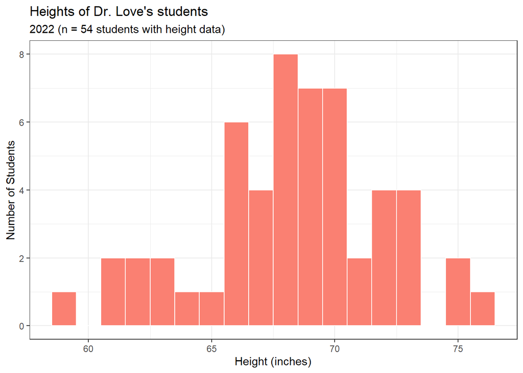

```r
dat3 <- qsdat |>
  filter(complete.cases(height_in)) |>
  filter(year == "2022")

ggplot(data = dat3, aes(x = height_in)) +
    geom_histogram(fill = "salmon", col = "white", binwidth = 1) +
    labs(title = "Heights of Dr. Love's students",
         subtitle = "2022 (n = 54 students with height data)",
         y = "Number of Students", x = "Height (inches)")
```

- How did we use the two `filter()` statements?
- Why might I have changed from specifying `bins` to `binwidth` here?

## 6.5 Checking the 1-SD Empirical Rule

- Of the 54 students in 2022 with heights, how many were within 1 SD of the mean?
  - Mean = 68.4, SD = 3.7.
  - 68.4 - 3.7 = 64.7 inches and 68.4 + 3.7 = 72.1 inches

```r
qsdat |> filter(complete.cases(height_in)) |>
    filter(year == "2022") |>
    count(height_in >= 64.7 & height_in <= 72.1)
```

```
# A tibble: 2 × 2
  `height_in >= 64.7 & height_in <= 72.1`     n
  <lgl>                                   <int>
1 FALSE                                      15
2 TRUE                                       39
```

## 6.6 2-SD Empirical Rule

- How many of the 54 `height_in` values gathered in 2022 were between 68.4 - 2(3.7) = 61.0 and 68.4 + 2(3.7) = 75.8 inches?

```r
qsdat |> filter(complete.cases(height_in)) |>
    filter(year == "2022") |>
    count(height_in >= 61.0 & height_in <= 75.8)
```

```
# A tibble: 2 × 2
  `height_in >= 61 & height_in <= 75.8`     n
  <lgl>                                 <int>
1 FALSE                                     2
2 TRUE                                     52
```

## 6.7 3-SD Empirical Rule

- How many of the 54 `height_in` values gathered in 2022 were between 68.4 - 3(3.7) = 57.3 and 68.4 + 3(3.7) = 79.5 inches?

```r
qsdat |> filter(complete.cases(height_in)) |>
    filter(year == "2022") |>
    count(height_in >= 57.3 & height_in <= 79.5)
```

```
# A tibble: 1 × 2
  `height_in >= 57.3 & height_in <= 79.5`     n
  <lgl>                                   <int>
1 TRUE                                       54
```

## 6.8 Empirical Rule Table for 2022 data

- $\bar{x}$ = sample mean, $s$ = sample SD
- For `height_in`: $n$ = 54 with data, $\bar{x} = 68.4, s = 3.7$
- For `pulse`: $n$ = 52 with data, $\bar{x} = 75.4, s = 11.2$

| Range | “Normal” | `height_in` | `pulse` |
| --- | --- | --- | --- |
| $\bar{x} \pm s$ | ~68% | $\frac{39}{54}$ = 72.2% | $\frac{43}{52}$ = 82.7% |
| $\bar{x} \pm 2\times s$ | ~95% | $\frac{52}{54}$ = 96.3% | $\frac{51}{52}$ = 98.1% |
| $\bar{x} \pm 3\times s$ | ~99.7% | $\frac{54}{54}$ = 100% | $\frac{52}{52}$ = 100% |

## 6.9 Boxplots of Height and of Pulse Rate

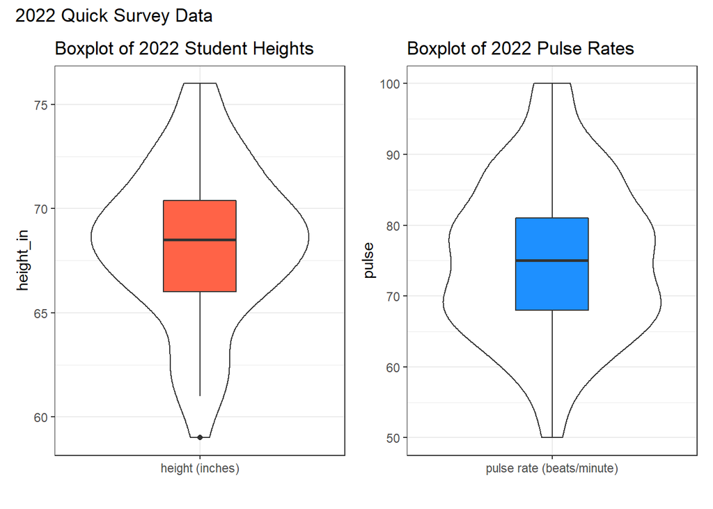

```r
dat4 <- qsdat |> filter(complete.cases(height_in), year == "2022")

p4 <- ggplot(data = dat4, aes(x = "height (inches)", y = height_in)) +
  geom_violin() + geom_boxplot(width = 0.3, fill = "tomato") +
  labs(title = "Boxplot of 2022 Student Heights", x = "")

dat5 <- qsdat |> filter(complete.cases(pulse), year == "2022")

p5 <- ggplot(data = dat5, aes(x = "pulse rate (beats/minute)", y = pulse)) +
  geom_violin() + geom_boxplot(width = 0.3, fill = "dodgerblue") +
  labs(title = "Boxplot of 2022 Pulse Rates", x = "")

p4 + p5 +
  plot_annotation(title = "2022 Quick Survey Data")
```

## 6.10 Normality and Mean/SD as summaries

If the data are approximately Normally distributed (like `height_in` and `pulse`) we can safely use the sample mean and standard deviation as summaries. If not “Normal”, then …

- The median is a more robust summary of the center.
- For spread, we often use the 25th and 75th percentiles.

```r
dat3 <- qsdat |> filter(year == "2022")
mosaic::favstats(~ height_in, data = dat3)
```

```
 min Q1 median     Q3 max     mean       sd  n missing
  59 66   68.5 70.375  76 68.35185 3.742451 54       0
```

```r
mosaic::favstats(~ pulse, data = dat3)
```

```
 min Q1 median Q3 max     mean       sd  n missing
  50 68     75 81 100 75.40385 11.17466 52       2
```

## 6.11 A new quantitative variable

Let’s look at haircut prices, across all years.

```r
mosaic::favstats(~ haircut, data = qsdat)
```

```
 min Q1 median Q3 max     mean      sd   n missing
   0 14     20 40 250 30.17214 31.4079 485       9
```

Does it seem like the Normal model will be a good fit for these prices?

- Why or why not?
- What more information do you need to make a decision?

## 6.12 2022 Haircut Prices

### 6.12.1 Unsorted

```r
qsdat |> filter(year == "2022") |>
  select(haircut) |>
  as.vector() ## just to print it here horizontally
```

```
$haircut
 [1]   2  50   0  38  25  15   0  32  60  40  45  52  52   0  30  15
[17]  30  75  20   4  45  20  35   0  50  25  40 240  30   6  45  25
[33]   2  30  25  20 200  15  35   0  20  80  20  30  80  10  50  30
[49]  60  20  20  30   5  30
```

### 6.12.2 Sorted

```r
qsdat |> filter(year == "2022") |>
  select(haircut) |> arrange(haircut) |>
  as.vector() ## just to print it here horizontally
```

```
$haircut
 [1]   0   0   0   0   0   2   2   4   5   6  10  15  15  15  20  20
[17]  20  20  20  20  20  25  25  25  25  30  30  30  30  30  30  30
[33]  30  32  35  35  38  40  40  45  45  45  50  50  50  52  52  60
[49]  60  75  80  80 200 240
```

### 6.12.3 Counts

```r
qsdat |> filter(year == "2022") |>
  count(haircut)
```

```
# A tibble: 22 × 2
   haircut     n
     <dbl> <int>
 1       0     5
 2       2     2
 3       4     1
 4       5     1
 5       6     1
 6      10     1
 7      15     3
 8      20     7
 9      25     4
10      30     8
# … with 12 more rows
```

## 6.13 2022 Haircut Prices, tabulated

```r
qsdat |> filter(year == "2022") |> tabyl(haircut) |> adorn_pct_formatting()
```

```
 haircut n percent
       0 5    9.3%
       2 2    3.7%
       4 1    1.9%
       5 1    1.9%
       6 1    1.9%
      10 1    1.9%
      15 3    5.6%
      20 7   13.0%
      25 4    7.4%
      30 8   14.8%
      32 1    1.9%
      35 2    3.7%
      38 1    1.9%
      40 2    3.7%
      45 3    5.6%
      50 3    5.6%
      52 2    3.7%
      60 2    3.7%
      75 1    1.9%
      80 2    3.7%
     200 1    1.9%
     240 1    1.9%
```

## 6.14 Normality of Haircut prices?

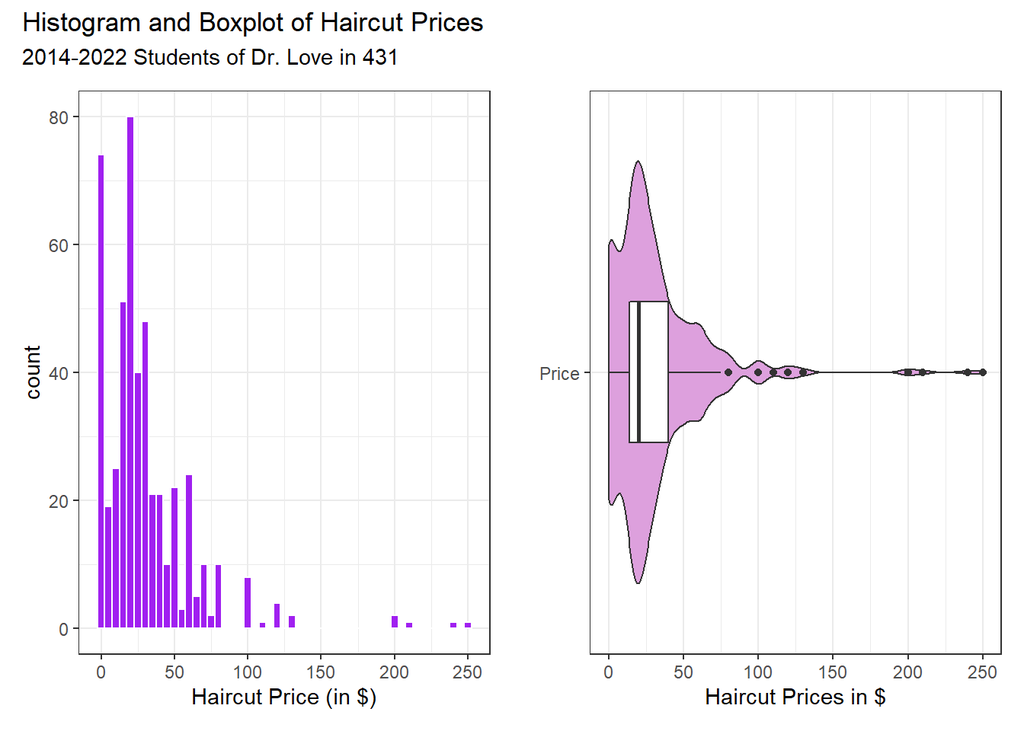

```r
dat6 <- qsdat |> filter(complete.cases(haircut))

p6a <- ggplot(data = dat6, aes(x = haircut)) +
  geom_histogram(binwidth = 5, fill = "purple", col = "white") +
  labs(x = "Haircut Price (in $)")

p6b <- ggplot(data = dat6, aes(x = haircut, y = "Price")) +
  geom_violin(fill = "plum") + geom_boxplot(width = 0.3) +
  labs(y = "", x = "Haircut Prices in $")

p6a + p6b +
  plot_annotation(
    title = "Histogram and Boxplot of Haircut Prices",
    subtitle = "2014-2022 Students of Dr. Love in 431")
```

- Do you think that the distribution of these prices follows a Normal model?

## 6.15 Stem-and-Leaf of Haircut Prices

```r
stem(qsdat$haircut, scale = 2) # scale makes plot twice as long as default
```

```
  The decimal point is 1 digit(s) to the right of the |

   0 | 00000000000000000000000000000000000000000000000000000000000000000000+19
   1 | 00000002222222222233444444445555555555555555555555555555555555556667
   2 | 00000000000000000000000000000000000000000000000000000000000000000012+34
   3 | 00000000000000000000000000000000000000122222255555555555555555555688
   4 | 000000000000000000035555555558
   5 | 000000000000000000022555
   6 | 00000000000000000000000055555
   7 | 000000002255
   8 | 0000000000
   9 |
  10 | 00000000
  11 | 0
  12 | 0000
  13 | 00
  14 |
  15 |
  16 |
  17 |
  18 |
  19 |
  20 | 00
  21 | 0
  22 |
  23 |
  24 | 0
  25 | 0
```

## 6.16 Empirical Rule Table for Haircut Prices

Let’s look across all years, as well as just in 2022

```r
mosaic::favstats(~ haircut, data = qsdat)
```

```
 min Q1 median Q3 max     mean      sd   n missing
   0 14     20 40 250 30.17214 31.4079 485       9
```

```r
mosaic::favstats(~ haircut, data = qsdat |> filter(year == "2022"))
```

```
 min    Q1 median Q3 max     mean       sd  n missing
   0 16.25     30 45 240 36.25926 41.81955 54       0
```

[output not shown]

## 6.17 How did I calculate those fractions?

```r
# haircut price mean = 30.17 and sd = 31.41 across 2014-2022

qsdat |> count(haircut >= 30.17 - 31.41 & haircut <= 30.17 + 31.41)
```

```
# A tibble: 3 × 2
  `haircut >= 30.17 - 31.41 & haircut <= 30.17 + 31.41`     n
  <lgl>                                                 <int>
1 FALSE                                                    47
2 TRUE                                                    438
3 NA                                                        9
```

```r
qsdat |> count(haircut >= 30.17 - 2*31.41 & haircut <= 30.17 + 2*31.41)
```

```
# A tibble: 3 × 2
  `haircut >= 30.17 - 2 * 31.41 & haircut <= 30.17 + 2 * 31.41`     n
  <lgl>                                                         <int>
1 FALSE                                                            20
2 TRUE                                                            465
3 NA                                                                9
```

```r
qsdat |> count(haircut >= 30.17 - 3*31.41 & haircut <= 30.17 + 3*31.41)
```

```
# A tibble: 3 × 2
  `haircut >= 30.17 - 3 * 31.41 & haircut <= 30.17 + 3 * 31.41`     n
  <lgl>                                                         <int>
1 FALSE                                                             7
2 TRUE                                                            478
3 NA                                                                9
```

```r
# haircut price mean = 36.26 and sd = 41.82 in 2022 alone

qsdat |> filter(year == "2022") |>
  count(haircut >= 36.26 - 41.82 & haircut <= 36.26 + 41.82)
```

```
# A tibble: 2 × 2
  `haircut >= 36.26 - 41.82 & haircut <= 36.26 + 41.82`     n
  <lgl>                                                 <int>
1 FALSE                                                     4
2 TRUE                                                     50
```

```r
qsdat |> filter(year == "2022") |>
  count(haircut >= 36.26 - 2*41.82 & haircut <= 36.26 + 2*41.82)
```

```
# A tibble: 2 × 2
  `haircut >= 36.26 - 2 * 41.82 & haircut <= 36.26 + 2 * 41.82`     n
  <lgl>                                                         <int>
1 FALSE                                                             2
2 TRUE                                                             52
```

```r
qsdat |> filter(year == "2022") |>
  count(haircut >= 36.26 - 3*41.82 & haircut <= 36.26 + 3*41.82)
```

```
# A tibble: 2 × 2
  `haircut >= 36.26 - 3 * 41.82 & haircut <= 36.26 + 3 * 41.82`     n
  <lgl>                                                         <int>
1 FALSE                                                             2
2 TRUE                                                             52
```

# 7 Question 4

4. Do taller people appear to have paid less for their most recent haircut?

## 7.1 Do tall people pay less for haircuts?

Why might we think that they do, before we see the data?

- Convert our student heights from inches to centimeters…

```r
qsdat <- qsdat |> mutate(height_cm = height_in * 2.54)

qsdat |> select(student, height_in, height_cm) |> head()
```

```
# A tibble: 6 × 3
  student height_in height_cm
  <chr>       <dbl>     <dbl>
1 202201       69.5      177.
2 202202       63        160.
3 202203       73        185.
4 202204       70        178.
5 202205       59        150.
6 202206       68        173.
```

## 7.2 Initial Numerical Summaries

```r
qsdat |> filter(complete.cases(haircut, height_cm)) |>
  summarize(n = n(), median(haircut), median(height_cm), median(height_in))
```

```
# A tibble: 1 × 4
      n `median(haircut)` `median(height_cm)` `median(height_in)`
  <int>             <dbl>               <dbl>               <dbl>
1   483                20                170.                  67
```

## 7.3 A First Scatterplot

- We’ll include the straight line from a linear model, in red.

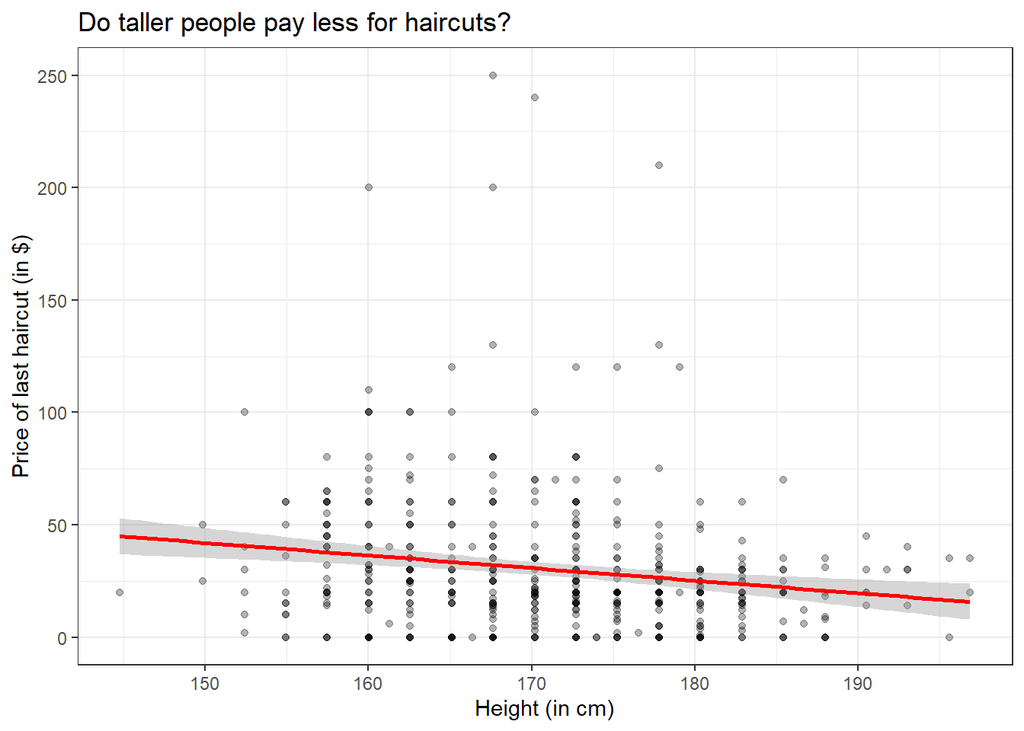

```r
dat7 <- qsdat |> filter(complete.cases(height_cm, haircut))

ggplot(dat7, aes(x = height_cm, y = haircut)) +
    geom_point(alpha = 0.3) +
    geom_smooth(method = "lm", col = "red",
                formula = y ~ x, se = TRUE) +
    labs(x = "Height (in cm)",
         y = "Price of last haircut (in $)",
         title = "Do taller people pay less for haircuts?")
```

## 7.4 What is the (Pearson) correlation of height and haircut price?

```r
dat7 <- qsdat |> filter(complete.cases(height_cm, haircut))

dat7 |>
    select(height_in, height_cm, haircut) |>
    cor()
```

```
           height_in  height_cm    haircut
height_in  1.0000000  1.0000000 -0.1708551
height_cm  1.0000000  1.0000000 -0.1708551
haircut   -0.1708551 -0.1708551  1.0000000
```

## 7.5 What is the straight line regression model?

```r
dat7 <- qsdat |> filter(complete.cases(height_cm, haircut))

mod1 <- lm(haircut ~ height_cm, data = dat7)

mod1
```

```
Call:
lm(formula = haircut ~ height_cm, data = dat7)

Coefficients:
(Intercept)    height_cm
   125.9519      -0.5597
```

## 7.6 Summarizing our model `mod1`

```r
summary(mod1)
```

```
Call:
lm(formula = haircut ~ height_cm, data = dat7)

Residuals:
    Min      1Q  Median      3Q     Max
-39.233 -18.124  -6.095   8.165 217.876

Coefficients:
            Estimate Std. Error t value Pr(>|t|)
(Intercept) 125.9519    25.2161   4.995 8.25e-07 ***
height_cm    -0.5597     0.1472  -3.803 0.000161 ***
---
Signif. codes:  0 '***' 0.001 '**' 0.01 '*' 0.05 '.' 0.1 ' ' 1

Residual standard error: 31.04 on 481 degrees of freedom
Multiple R-squared:  0.02919,   Adjusted R-squared:  0.02717
F-statistic: 14.46 on 1 and 481 DF,  p-value: 0.0001613
```

## 7.7 Compare `lm` fit to `loess` smooth curve?

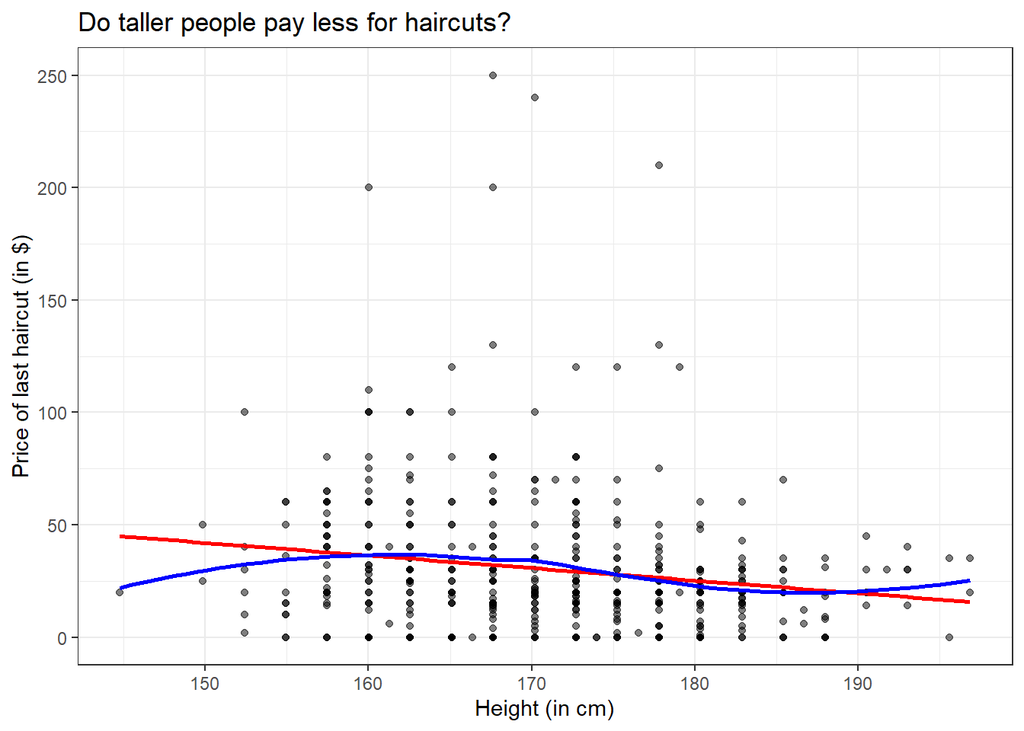

```r
dat7 <- qsdat |> filter(complete.cases(height_cm, haircut))

ggplot(dat7, aes(x = height_cm, y = haircut)) +
    geom_point(alpha = 0.5) +
    geom_smooth(method = "lm", col = "red",
                formula = y ~ x, se = FALSE) +
    geom_smooth(method = "loess", col = "blue",
                formula = y ~ x, se = FALSE) +
    labs(x = "Height (in cm)",
         y = "Price of last haircut (in $)",
         title = "Do taller people pay less for haircuts?")
```

- Does a linear model appear to fit these data well?
- Do taller people pay less for their haircuts?

# 8 Question 5

5. Do students have a more substantial tobacco history if they prefer to speak English or a language other than English?

## 8.1 Restrict ourselves to 2022 data

- Do students in the 2022 class have a more substantial history of tobacco use if they prefer to speak a language other than English?

```r
dat9 <- qsdat |>
    filter(year == "2022") |>
    select(student, year, english, smoke)
```

```r
summary(dat9)
```

```
   student               year    english smoke
 Length:54          2022   :54   n:16    1:47
 Class :character   2014   : 0   y:38    2: 6
 Mode  :character   2015   : 0           3: 1
                    2016   : 0
                    2017   : 0
                    2018   : 0
                    (Other): 0
```

No missing data.

## 8.2 Tabulating the categorical variables individually

```r
dat9 |> tabyl(english)
```

```
 english  n   percent
       n 16 0.2962963
       y 38 0.7037037
```

```r
dat9 |> tabyl(smoke) |> adorn_pct_formatting()
```

```
 smoke  n percent
     1 47   87.0%
     2  6   11.1%
     3  1    1.9%
```

## 8.3 Cross-Classification (2 rows $\times$ 3 columns)

```r
dat9 |> tabyl(english, smoke)
```

```
 english  1 2 3
       n 15 0 1
       y 32 6 0
```

## 8.4 Recode the `smoke` levels to more meaningful names in `tobacco`

```r
dat9 <- dat9 |>
    mutate(tobacco = fct_recode(smoke,
            "Never" = "1", "Quit" = "2", "Current" = "3"))
```

### 8.4.1 Check our work?

```r
dat9 |> count(smoke, tobacco)
```

```
# A tibble: 3 × 3
  smoke tobacco     n
  <fct> <fct>   <int>
1 1     Never      47
2 2     Quit        6
3 3     Current     1
```

- Everyone with `smoke` = 1 has `tobacco` as Never, etc.

## 8.5 Restate the cross-tabulation

Now we’ll use this new variable, and this time, add row and column totals.

```r
dat9 |> tabyl(english, tobacco) |>
    adorn_totals(where = c("row", "col"))
```

```
 english Never Quit Current Total
       n    15    0       1    16
       y    32    6       0    38
   Total    47    6       1    54
```

- What can we conclude about this association?

## 8.6 How about in 2014-2022?

```r
dat8 <- qsdat |>
  filter(complete.cases(english, smoke)) |>
  mutate(tobacco = fct_recode(smoke,
            "Never" = "1", "Quit" = "2", "Current" = "3"))

dat8 |>
  tabyl(english, tobacco) |>
  adorn_totals(where = c("row", "col"))
```

```
 english Never Quit Current Total
       n    95    2       4   101
       y   359   26       4   389
   Total   454   28       8   490
```

- Now, what is your conclusion?

# 9 Cleaning up the temporary objects

```r
rm(mod1,
   p4, p5, p6a, p6b,
   dat1, dat2, dat3, dat4, dat5, dat6, dat7, dat8, dat9
   )

## this just leaves
## qsdat and quicksur_raw in my Global Environment
```